# HR ANALYTICS and MODELING :

### Observations :

1. From min,max,mean and 50% ,we can little bit describe related to skewness but histogram give crystal clear picture

```python
tes_con.describe()
```

|  | no_of_trainings | age | length_of_service | avg_training_score |
| --- | --- | --- | --- | --- |
| count | 23490.000000 | 23490.000000 | 23490.000000 | 23490.000000 |
| mean | 1.254236 | 34.782929 | 5.810387 | 63.263133 |
| std | 0.600910 | 7.679492 | 4.207917 | 13.411750 |
| min | 1.000000 | 20.000000 | 1.000000 | 39.000000 |
| 25% | 1.000000 | 29.000000 | 3.000000 | 51.000000 |
| 50% | 1.000000 | 33.000000 | 5.000000 | 60.000000 |
| 75% | 1.000000 | 39.000000 | 7.000000 | 76.000000 |
| max | 9.000000 | 60.000000 | 34.000000 | 99.000000 |

```
For train data :
```

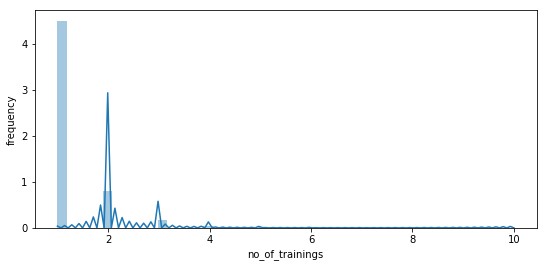

```
Skewness :  3.445433937567454
```

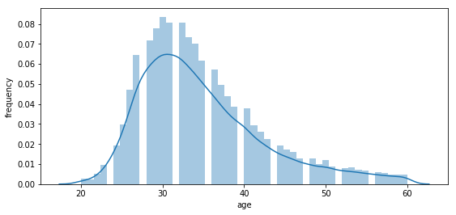

```
Skewness :  1.0074317710382241
```

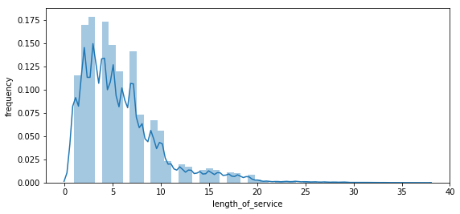

```
Skewness :  1.738061458740809
```

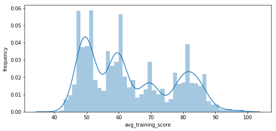

```
Skewness :  0.45190808551707995
For test data :
```

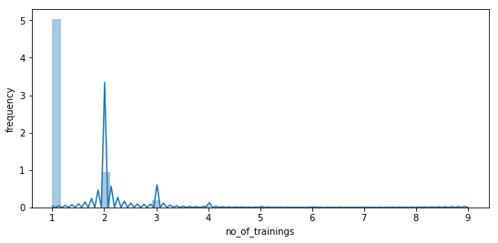

```
Skewness :  3.299829240353573
```

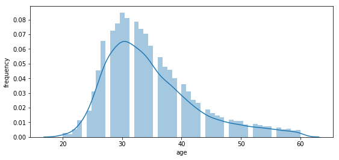

```
Skewness :  1.0117773507112382
```

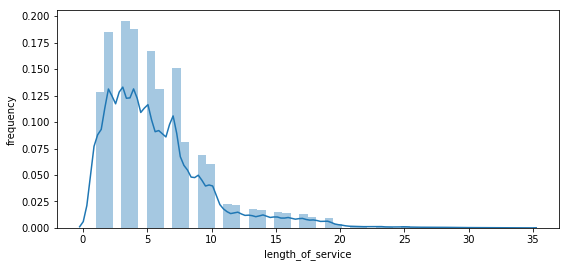

```
Skewness :  1.7030008581343499
```

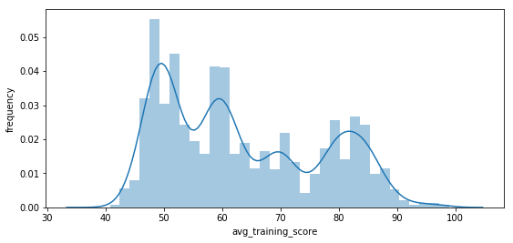

```
Skewness :  0.4581131346053442
```

```python
print("For train data :")
for i in tra_con.columns.tolist():
    plt.figure(figsize=(9,4))
    sns.distplot(tra_con[i])
    plt.ylabel('frequency')
    plt.show()
    print("Skewness : ",tra_con[i].skew())

print("*"*71)

print("For test data :")
for i in tes_con.columns.tolist():
    plt.figure(figsize=(9,4))
    sns.distplot(tes_con[i])
    plt.ylabel('frequency')
    plt.show()
    print("Skewness : ",tes_con[i].skew())
```

### Observations :

1. Some of the graph is little bit skewed but still fine.
2. The data in train and test is almost similar,we can observe each column corresponding graph for both dataset.

### 4.2 Categorical Variables :

```
train categorical data:

Column :  department
```

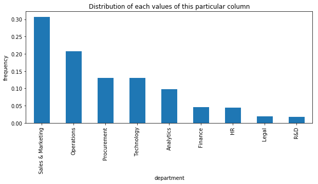

```
Column :  region
```

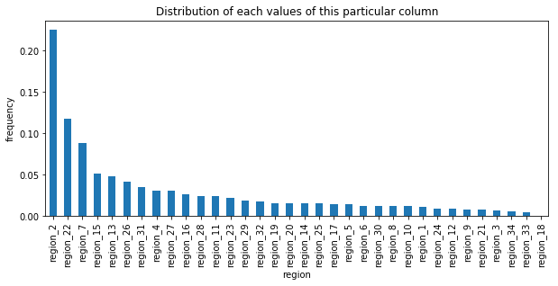

```
Column :  education
```

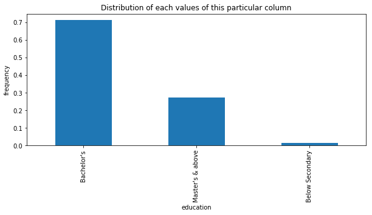

```
Column :  gender
```

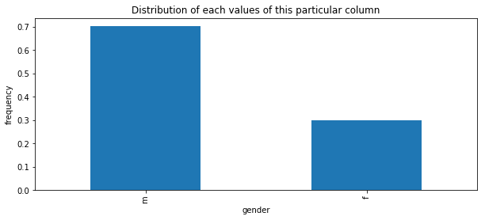

```
Column :  recruitment_channel
```

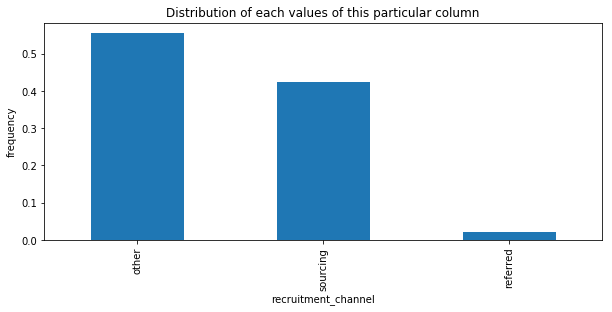

```
Column :  previous_year_rating
```

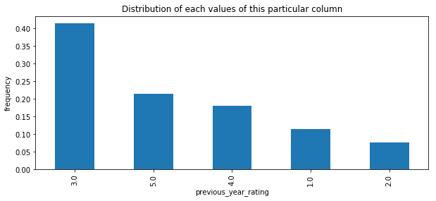

```
Column :  KPIs_met >80%
```

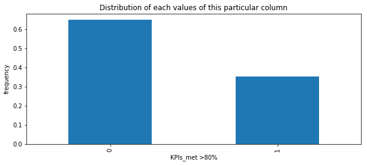

```
Column :  awards_won?
```

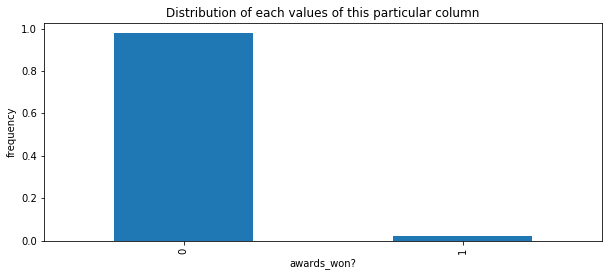

```
Column :  is_promoted
```

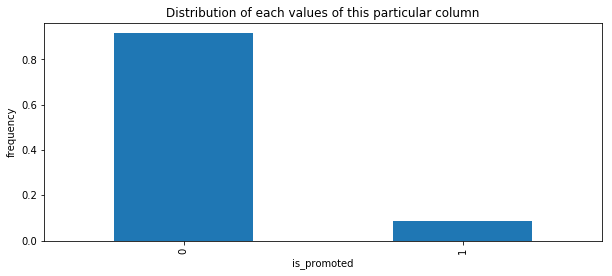

```
test categorical data:

Column :  department
```

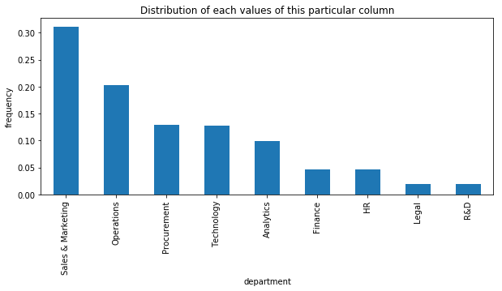

```
Column :  region
```

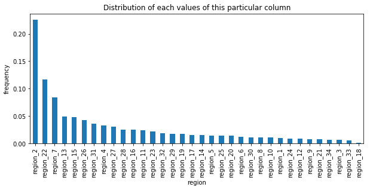

```
Column :  education
```

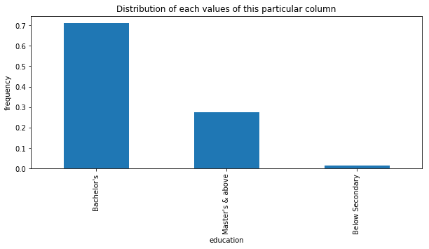

```
Column :  gender
```

[5 more figures not shown]

```python
# plotting barplot to observe the % of value for each column

print("train categorical data:\n")
for i in tra_cat.columns.tolist():
    print("Column : ",i)
    plt.figure(figsize=(10,4))
    tra_cat[i].value_counts(normalize=True).plot.bar()
    plt.title("Distribution of each values of this particular column")
    plt.xlabel(i)
    plt.ylabel("frequency")
    plt.show()
    print("*"*71)


print("*"*71)
print("*"*71)

print("test categorical data:\n")
for i in tes_cat.columns.tolist():
    print("Column : ",i)
    plt.figure(figsize=(10,4))
    tes_cat[i].value_counts(normalize=True).plot.bar()
    plt.title("Distribution of each values of this particular column")
    plt.xlabel(i)
    plt.ylabel("frequency")
    plt.show()
    print("*"*71)
```

## 5. Bivariate Analysis :

### 5.1 Continuous-Continuous Variables:

```python
# instead of using tra_con,I am using train because .corr() gives correlation between any numerical
# data present in our dataset

train.corr()
```

|  | no_of_trainings | age | previous_year_rating | length_of_service | KPIs_met >80% | awards_won? | avg_training_score | is_promoted |
| --- | --- | --- | --- | --- | --- | --- | --- | --- |
| no_of_trainings | 1.000000 | -0.081278 | -0.061564 | -0.057275 | -0.045576 | -0.007628 | 0.042517 | -0.024896 |
| age | -0.081278 | 1.000000 | 0.026810 | 0.657111 | -0.025592 | -0.008169 | -0.048380 | -0.017166 |
| previous_year_rating | -0.061564 | 0.026810 | 1.000000 | 0.023504 | 0.337367 | 0.026587 | 0.071926 | 0.153230 |
| length_of_service | -0.057275 | 0.657111 | 0.023504 | 1.000000 | -0.077693 | -0.039927 | -0.038122 | -0.010670 |
| KPIs_met >80% | -0.045576 | -0.025592 | 0.337367 | -0.077693 | 1.000000 | 0.097000 | 0.078391 | 0.221582 |
| awards_won? | -0.007628 | -0.008169 | 0.026587 | -0.039927 | 0.097000 | 1.000000 | 0.072138 | 0.195871 |
| avg_training_score | 0.042517 | -0.048380 | 0.071926 | -0.038122 | 0.078391 | 0.072138 | 1.000000 | 0.181147 |
| is_promoted | -0.024896 | -0.017166 | 0.153230 | -0.010670 | 0.221582 | 0.195871 | 0.181147 | 1.000000 |

```python
test.corr()
```

|  | no_of_trainings | age | previous_year_rating | length_of_service | KPIs_met >80% | awards_won? | avg_training_score |
| --- | --- | --- | --- | --- | --- | --- | --- |
| no_of_trainings | 1.000000 | -0.085509 | -0.047281 | -0.061095 | -0.040020 | 0.001892 | 0.048121 |
| age | -0.085509 | 1.000000 | 0.037746 | 0.644515 | -0.027661 | -0.005457 | -0.035823 |
| previous_year_rating | -0.047281 | 0.037746 | 1.000000 | 0.027444 | 0.334821 | 0.026392 | 0.060751 |
| length_of_service | -0.061095 | 0.644515 | 0.027444 | 1.000000 | -0.078121 | -0.042083 | -0.028643 |
| KPIs_met >80% | -0.040020 | -0.027661 | 0.334821 | -0.078121 | 1.000000 | 0.108288 | 0.072981 |
| awards_won? | 0.001892 | -0.005457 | 0.026392 | -0.042083 | 0.108288 | 1.000000 | 0.073857 |
| avg_training_score | 0.048121 | -0.035823 | 0.060751 | -0.028643 | 0.072981 | 0.073857 | 1.000000 |

### Observations :

1. The correlation of any numerical variables with target variable is very less and this may create problem in terms of performance

### 5.2 Continuous-Categorical Variables:

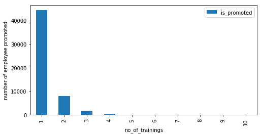

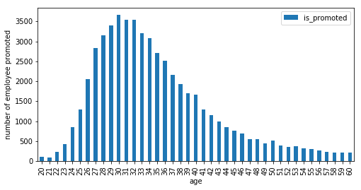

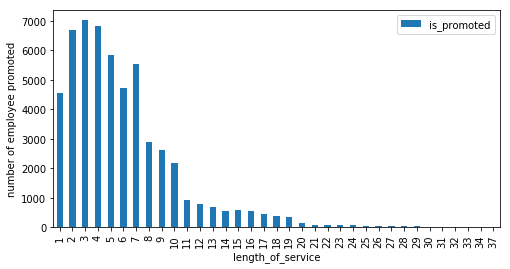

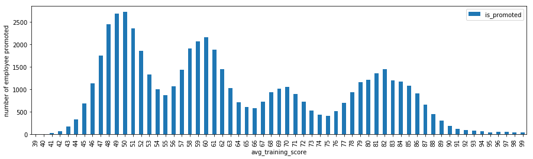

```python
# checking % of employee promoted with respect to other continuous variables
#Note that value on y-axis is average because pivot_table by default uses aggfunct=average

pd.pivot_table(data=train,index='no_of_trainings',values='is_promoted',aggfunc=len).plot(kind='bar',figsize=(8,4))
plt.ylabel('number of employee promoted')
plt.show()

pd.pivot_table(data=train,index='age',values='is_promoted',aggfunc=len).plot(kind='bar',figsize=(8,4))
plt.ylabel('number of employee promoted')
plt.show()

pd.pivot_table(data=train,index='length_of_service',values='is_promoted',aggfunc=len).plot(kind='bar',figsize=(8,4))
plt.ylabel('number of employee promoted')
plt.show()

pd.pivot_table(data=train,index='avg_training_score',values='is_promoted',aggfunc=len).plot(kind='bar',figsize=(15,4))
plt.ylabel('number of employee promoted')
plt.show()
```

### Observations :

```python
# for train data

bins = [19,20, 27, 35, 46, 60]
names = ['<=20','20-27', '28-35', '36-46', '47-60']

train['Age'] = pd.cut(train['age'], bins, labels=names)

train.head()
```

|  | department | region | education | gender | recruitment_channel | no_of_trainings | age | previous_year_rating | length_of_service | KPIs_met >80% | awards_won? | avg_training_score | is_promoted | Age |
| --- | --- | --- | --- | --- | --- | --- | --- | --- | --- | --- | --- | --- | --- | --- |
| 0 | Sales & Marketing | region_7 | Master's & above | f | sourcing | 1 | 35 | 5.0 | 8 | 1 | 0 | 49 | 0 | 28-35 |
| 1 | Operations | region_22 | Bachelor's | m | other | 1 | 30 | 5.0 | 4 | 0 | 0 | 60 | 0 | 28-35 |
| 2 | Sales & Marketing | region_19 | Bachelor's | m | sourcing | 1 | 34 | 3.0 | 7 | 0 | 0 | 50 | 0 | 28-35 |
| 3 | Sales & Marketing | region_23 | Bachelor's | m | other | 2 | 39 | 1.0 | 10 | 0 | 0 | 50 | 0 | 36-46 |
| 4 | Technology | region_26 | Bachelor's | m | other | 1 | 45 | 3.0 | 2 | 0 | 0 | 73 | 0 | 36-46 |

```python
test['Age'] = pd.cut(test['age'], bins, labels=names)

train.head()
```

|  | department | region | education | gender | recruitment_channel | no_of_trainings | age | previous_year_rating | length_of_service | KPIs_met >80% | awards_won? | avg_training_score | is_promoted | Age |
| --- | --- | --- | --- | --- | --- | --- | --- | --- | --- | --- | --- | --- | --- | --- |
| 0 | Sales & Marketing | region_7 | Master's & above | f | sourcing | 1 | 35 | 5.0 | 8 | 1 | 0 | 49 | 0 | 28-35 |
| 1 | Operations | region_22 | Bachelor's | m | other | 1 | 30 | 5.0 | 4 | 0 | 0 | 60 | 0 | 28-35 |
| 2 | Sales & Marketing | region_19 | Bachelor's | m | sourcing | 1 | 34 | 3.0 | 7 | 0 | 0 | 50 | 0 | 28-35 |
| 3 | Sales & Marketing | region_23 | Bachelor's | m | other | 2 | 39 | 1.0 | 10 | 0 | 0 | 50 | 0 | 36-46 |
| 4 | Technology | region_26 | Bachelor's | m | other | 1 | 45 | 3.0 | 2 | 0 | 0 | 73 | 0 | 36-46 |

### Observation :

1. Must play around boundary value of bins and labels to get the idea of boundary case.
2. Must first check lowest and highest value for that particular column(in both datasets) before creating bins.
3. Age column now become categorical column.
4. How to convert continuous into categorical : https://stackoverflow.com/questions/15891038/change-data-type-of-columns-in-pandas

```python
# now dropping age column
# now age becomes categorical variables

train=train.drop('age',1)
test=test.drop('age',1)

#renaming 'Age' to 'age'

train.rename({'Age':'age'},axis=1,inplace=True)
test.rename({'Age':'age'},axis=1,inplace=True)
```

### 5.3 Categorical-Categorical Variables:

```python
# next two statement (line) related to this code only but due to I want to see what result each steps
# are giving,I had breaked into more line

depart_count = train.groupby(["gender", "is_promoted"])["is_promoted"].count()
depart_count
```

```
gender  is_promoted
f       0              14845
        1               1467
m       0              35295
        1               3201
Name: is_promoted, dtype: int64
```

```python
depart_count.unstack()#.plot(kind='bar', stacked=True)
```

| is_promoted gender | 0 | 1 |
| --- | --- | --- |
| f | 14845 | 1467 |
| m | 35295 | 3201 |

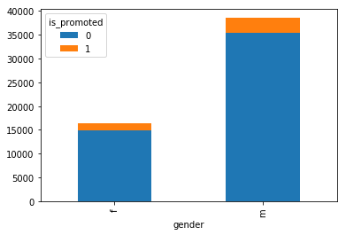

```python
depart_count.unstack().plot(kind='bar', stacked=True)
```

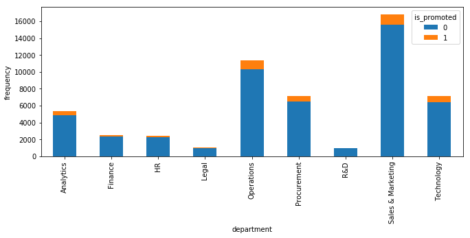

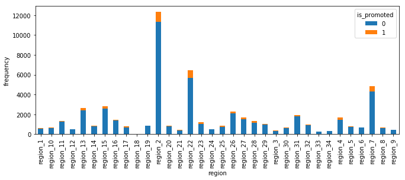

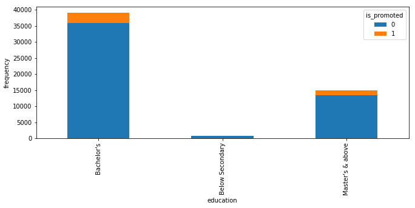

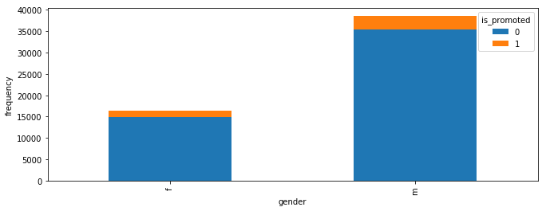

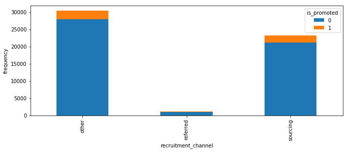

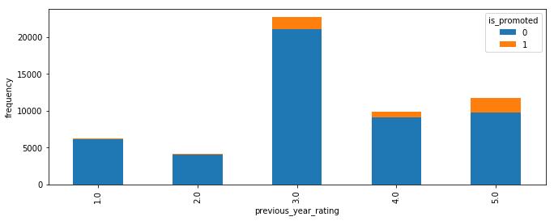

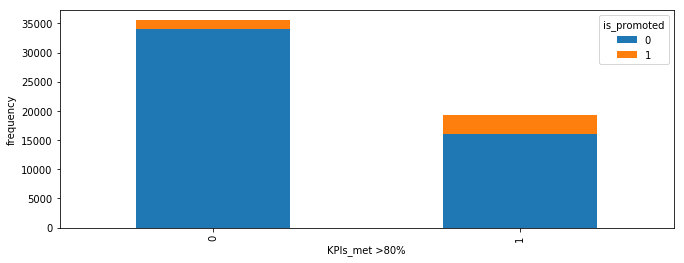

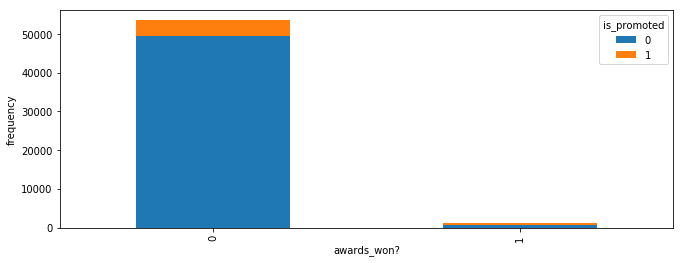

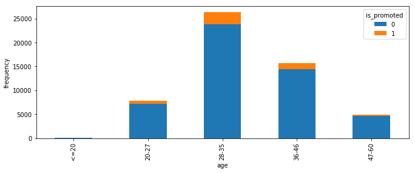

```python
for i in tes_cat.columns.tolist():
    #plt.figure(figsize=(11,4))
    train.groupby([i,'is_promoted'])['is_promoted'].count().unstack().plot(kind='bar',stacked=True,figsize=(11,4))
    plt.ylabel('frequency')
    plt.show()
    print('*'*95)

train.groupby(['age','is_promoted'])['is_promoted'].count().unstack().plot(kind='bar',stacked=True,figsize=(11,4))
plt.ylabel('frequency')
plt.show()
```

Reference :

1. https://robertmitchellv.com/blog-bar-chart-annotations-pandas-mpl.html

## 6. Outliers Treatment:

1. No need of this step as all values lies in certain range

### Important links :

1. https://www.analyticsvidhya.com/blog/2016/01/12-pandas-techniques-python-data-manipulation/
2. https://data-flair.training/blogs/pandas-function-applications/

## 7. Feature Engineering :

```python
# first doing this thing for train test(in multi step)
# then combine all steps into single for test data

# separating nominal(dummies) and ordinal(label encoder or manually) categorical
# Because both requires different method

ord_var=['education','age']
nom_var=['department','region','gender','recruitment_channel']
```

```python
# ordinal part
# this step also change datatype of these variables from object to int

train['education']=train['education'].map({'Below Secondary':0,"Bachelor's":1,"Master's & above":2})
train['age']=train['age'].map({'<=20':0,'20-27':1,'28-35':2,'36-46':3,'47-60':4})
```

```python
# dummies part

def categorical_to_dummies(train):
    list_to_drop = []
    for col in train.columns:
        if train[col].dtype == 'object':
            print("Converting....", col)
            list_to_drop.append(col)
            train = pd.concat([train, pd.get_dummies(train[col], prefix=col, prefix_sep='_', drop_first=True)], axis=1)
    return train, list_to_drop
```

```python
train.head()
```

|  | department | region | education | gender | recruitment_channel | no_of_trainings | previous_year_rating | length_of_service | KPIs_met >80% | awards_won? | avg_training_score | is_promoted | age |
| --- | --- | --- | --- | --- | --- | --- | --- | --- | --- | --- | --- | --- | --- |
| 0 | Sales & Marketing | region_7 | 2 | f | sourcing | 1 | 5.0 | 8 | 1 | 0 | 49 | 0 | 2 |
| 1 | Operations | region_22 | 1 | m | other | 1 | 5.0 | 4 | 0 | 0 | 60 | 0 | 2 |
| 2 | Sales & Marketing | region_19 | 1 | m | sourcing | 1 | 3.0 | 7 | 0 | 0 | 50 | 0 | 2 |
| 3 | Sales & Marketing | region_23 | 1 | m | other | 2 | 1.0 | 10 | 0 | 0 | 50 | 0 | 3 |
| 4 | Technology | region_26 | 1 | m | other | 1 | 3.0 | 2 | 0 | 0 | 73 | 0 | 3 |

```python
train, list_to_drop =categorical_to_dummies(train)
train.head()
```

```
Converting.... department
Converting.... region
Converting.... gender
Converting.... recruitment_channel
```

|  | department | region | education | gender | recruitment_channel | no_of_trainings | previous_year_rating | length_of_service | KPIs_met >80% | awards_won? | ... | region_region_34 | region_region_4 | region_region_5 | region_region_6 | region_region_7 | region_region_8 | region_region_9 | gender_m | recruitment_channel_referred | recruitment_channel_sourcing |
| --- | --- | --- | --- | --- | --- | --- | --- | --- | --- | --- | --- | --- | --- | --- | --- | --- | --- | --- | --- | --- | --- |
| 0 | Sales & Marketing | region_7 | 2 | f | sourcing | 1 | 5.0 | 8 | 1 | 0 | ... | 0 | 0 | 0 | 0 | 1 | 0 | 0 | 0 | 0 | 1 |
| 1 | Operations | region_22 | 1 | m | other | 1 | 5.0 | 4 | 0 | 0 | ... | 0 | 0 | 0 | 0 | 0 | 0 | 0 | 1 | 0 | 0 |
| 2 | Sales & Marketing | region_19 | 1 | m | sourcing | 1 | 3.0 | 7 | 0 | 0 | ... | 0 | 0 | 0 | 0 | 0 | 0 | 0 | 1 | 0 | 1 |
| 3 | Sales & Marketing | region_23 | 1 | m | other | 2 | 1.0 | 10 | 0 | 0 | ... | 0 | 0 | 0 | 0 | 0 | 0 | 0 | 1 | 0 | 0 |
| 4 | Technology | region_26 | 1 | m | other | 1 | 3.0 | 2 | 0 | 0 | ... | 0 | 0 | 0 | 0 | 0 | 0 | 0 | 1 | 0 | 0 |

5 rows × 57 columns

```python
print("Total shape of Data :", train.shape)
print("Columns which need to be dropped :", list_to_drop)
train = train.drop(list_to_drop, axis = 1)
print("Total shape of Data :", train.shape)
```

```
Total shape of Data : (54808, 57)
Columns which need to be dropped : ['department', 'region', 'gender', 'recruitment_channel']
Total shape of Data : (54808, 53)
```

```python
train.head()
```

|  | education | no_of_trainings | previous_year_rating | length_of_service | KPIs_met >80% | awards_won? | avg_training_score | is_promoted | age | department_Finance | ... | region_region_34 | region_region_4 | region_region_5 | region_region_6 | region_region_7 | region_region_8 | region_region_9 | gender_m | recruitment_channel_referred | recruitment_channel_sourcing |
| --- | --- | --- | --- | --- | --- | --- | --- | --- | --- | --- | --- | --- | --- | --- | --- | --- | --- | --- | --- | --- | --- |
| 0 | 2 | 1 | 5.0 | 8 | 1 | 0 | 49 | 0 | 2 | 0 | ... | 0 | 0 | 0 | 0 | 1 | 0 | 0 | 0 | 0 | 1 |
| 1 | 1 | 1 | 5.0 | 4 | 0 | 0 | 60 | 0 | 2 | 0 | ... | 0 | 0 | 0 | 0 | 0 | 0 | 0 | 1 | 0 | 0 |
| 2 | 1 | 1 | 3.0 | 7 | 0 | 0 | 50 | 0 | 2 | 0 | ... | 0 | 0 | 0 | 0 | 0 | 0 | 0 | 1 | 0 | 1 |
| 3 | 1 | 2 | 1.0 | 10 | 0 | 0 | 50 | 0 | 3 | 0 | ... | 0 | 0 | 0 | 0 | 0 | 0 | 0 | 1 | 0 | 0 |
| 4 | 1 | 1 | 3.0 | 2 | 0 | 0 | 73 | 0 | 3 | 0 | ... | 0 | 0 | 0 | 0 | 0 | 0 | 0 | 1 | 0 | 0 |

5 rows × 53 columns

```python
# checking now datatype of each column

train.info()
```

```
<class 'pandas.core.frame.DataFrame'>
RangeIndex: 54808 entries, 0 to 54807
Data columns (total 53 columns):
education                       54808 non-null int64
no_of_trainings                 54808 non-null int64
previous_year_rating            54808 non-null float64
length_of_service               54808 non-null int64
KPIs_met >80%                   54808 non-null int64
awards_won?                     54808 non-null int64
avg_training_score              54808 non-null int64
is_promoted                     54808 non-null int64
age                             54808 non-null int64
department_Finance              54808 non-null uint8
department_HR                   54808 non-null uint8
department_Legal                54808 non-null uint8
department_Operations           54808 non-null uint8
department_Procurement          54808 non-null uint8
department_R&D                  54808 non-null uint8
department_Sales & Marketing    54808 non-null uint8
department_Technology           54808 non-null uint8
region_region_10                54808 non-null uint8
region_region_11                54808 non-null uint8
region_region_12                54808 non-null uint8
region_region_13                54808 non-null uint8
region_region_14                54808 non-null uint8
region_region_15                54808 non-null uint8
region_region_16                54808 non-null uint8
region_region_17                54808 non-null uint8
region_region_18                54808 non-null uint8
region_region_19                54808 non-null uint8
region_region_2                 54808 non-null uint8
region_region_20                54808 non-null uint8
region_region_21                54808 non-null uint8
region_region_22                54808 non-null uint8
region_region_23                54808 non-null uint8
region_region_24                54808 non-null uint8
region_region_25                54808 non-null uint8
region_region_26                54808 non-null uint8
region_region_27                54808 non-null uint8
region_region_28                54808 non-null uint8
region_region_29                54808 non-null uint8
region_region_3                 54808 non-null uint8
region_region_30                54808 non-null uint8
region_region_31                54808 non-null uint8
region_region_32                54808 non-null uint8
region_region_33                54808 non-null uint8
region_region_34                54808 non-null uint8
region_region_4                 54808 non-null uint8
region_region_5                 54808 non-null uint8
region_region_6                 54808 non-null uint8
region_region_7                 54808 non-null uint8
region_region_8                 54808 non-null uint8
region_region_9                 54808 non-null uint8
gender_m                        54808 non-null uint8
recruitment_channel_referred    54808 non-null uint8
recruitment_channel_sourcing    54808 non-null uint8
dtypes: float64(1), int64(8), uint8(44)
memory usage: 6.1 MB
```

```python
test['education']=test['education'].map({'Below Secondary':0,"Bachelor's":1,"Master's & above":2})
test['age']=test['age'].map({'<=20':0,'20-27':1,'28-35':2,'36-46':3,'47-60':4})

# dummies part

def categorical_to_dummies(test):
    list_to_drop = []
    for col in test.columns:
        if test[col].dtype == 'object':
            print("Converting....", col)
            list_to_drop.append(col)
            test = pd.concat([test, pd.get_dummies(test[col], prefix=col, prefix_sep='_', drop_first=True)], axis=1)
    return test, list_to_drop
```

```python
test, list_to_drop =categorical_to_dummies(test)
print("Total shape of Data :", test.shape)
print("Columns which need to be dropped :", list_to_drop)
test = test.drop(list_to_drop, axis = 1)
print("Total shape of Data :", test.shape)
```

```
Converting.... department
Converting.... region
Converting.... gender
Converting.... recruitment_channel
Total shape of Data : (23490, 56)
Columns which need to be dropped : ['department', 'region', 'gender', 'recruitment_channel']
Total shape of Data : (23490, 52)
```

```python
test.head()
```

|  | education | no_of_trainings | previous_year_rating | length_of_service | KPIs_met >80% | awards_won? | avg_training_score | age | department_Finance | department_HR | ... | region_region_34 | region_region_4 | region_region_5 | region_region_6 | region_region_7 | region_region_8 | region_region_9 | gender_m | recruitment_channel_referred | recruitment_channel_sourcing |
| --- | --- | --- | --- | --- | --- | --- | --- | --- | --- | --- | --- | --- | --- | --- | --- | --- | --- | --- | --- | --- | --- |
| 0 | 2 | 1 | 3.0 | 1 | 1 | 0 | 77 | 1 | 0 | 0 | ... | 0 | 0 | 0 | 0 | 0 | 0 | 0 | 1 | 0 | 1 |
| 1 | 1 | 1 | 3.0 | 5 | 0 | 0 | 51 | 2 | 0 | 1 | ... | 0 | 1 | 0 | 0 | 0 | 0 | 0 | 0 | 0 | 0 |
| 2 | 1 | 1 | 1.0 | 4 | 0 | 0 | 47 | 2 | 0 | 0 | ... | 0 | 0 | 0 | 0 | 0 | 0 | 0 | 1 | 0 | 0 |
| 3 | 1 | 3 | 2.0 | 9 | 0 | 0 | 65 | 2 | 0 | 0 | ... | 0 | 0 | 0 | 0 | 0 | 0 | 0 | 0 | 0 | 0 |
| 4 | 1 | 1 | 4.0 | 7 | 0 | 0 | 61 | 2 | 1 | 0 | ... | 0 | 0 | 0 | 0 | 0 | 0 | 0 | 1 | 0 | 1 |

5 rows × 52 columns

## 8. Modeling

```python
# this step is added after forming models(all four) first time and I got good accuracy but poor recall
# ,precision,f1_score due to unbalanced value in target column

# so after I taught to go for upsampling and downsampling

train_1=train.copy()
train_2=train.copy()
train_3=train.copy()
train_4=train.copy()
train_5=train.copy() # extra created,if in future,I will create more model
```

### 8.1 Brute Force Technique

```python
# splitting data into train and test

y=train.pop('is_promoted')
x=train

from sklearn.model_selection import train_test_split

x_train,x_test,y_train,y_test=train_test_split(x,y,train_size=0.8,random_state=51)
print("x_train dimension : ",x_train.shape)
print("x_test dimension : ",x_test.shape)
print("y_train dimension : ",y_train.shape)
print("y_test dimension : ",y_test.shape)
```

```
x_train dimension :  (43846, 52)
x_test dimension :  (10962, 52)
y_train dimension :  (43846,)
y_test dimension :  (10962,)
```

```python
from sklearn.linear_model import LogisticRegression
from sklearn.neighbors import KNeighborsClassifier
from sklearn.tree import DecisionTreeClassifier
from sklearn.ensemble import RandomForestClassifier

lr = LogisticRegression()
knn = KNeighborsClassifier()
dtc = DecisionTreeClassifier()
rfc = RandomForestClassifier()
```

```python
fit1 = lr.fit(x_train,y_train) #fitting training data to Logistic Regression
fit2 = knn.fit(x_train,y_train) #fitting training data to knn
fit3 = dtc.fit(x_train,y_train) #fitting training data to Decision Tree Classifier
fit4 = rfc.fit(x_train,y_train) #fitting training data to Random Forest Classifier
```

```python
print("Accuracy Score of Logistic regression on train set",fit1.score(x_train,y_train)*100)
print("Accuracy Score of knn on train set",fit2.score(x_train,y_train)*100)
print("Accuracy Score of Decision Tree on train set",fit3.score(x_train,y_train)*100)
print("Accuracy Score of Random Forest on train set",fit4.score(x_train,y_train)*100)
```

```
Accuracy Score of Logistic regression on train set 93.0027824659034
Accuracy Score of knn on train set 93.47260867581991
Accuracy Score of Decision Tree on train set 99.86771883410117
Accuracy Score of Random Forest on train set 98.8528029922912
```

```python
# this is equivalent to accuracy_score but this I had shown just to show result

print("Accuracy Score of Logistic regression on test set",fit1.score(x_test,y_test)*100)
print("Accuracy Score of knn on test set",fit2.score(x_test,y_test)*100)
print("Accuracy Score of Decision Tree on test set",fit3.score(x_test,y_test)*100)
print("Accuracy Score of Random Forest on test set",fit4.score(x_test,y_test)*100)
```

```
Accuracy Score of Logistic regression on test set 93.06695858419997
Accuracy Score of knn on test set 92.56522532384601
Accuracy Score of Decision Tree on test set 90.12041598248494
Accuracy Score of Random Forest on test set 93.05783616128444
```

```python
# predicting target variable value for x_test dataset

y_pred1=fit1.predict(x_test)
y_pred2=fit2.predict(x_test)
y_pred3=fit3.predict(x_test)
y_pred4=fit4.predict(x_test)
```

```python
# importing performance metrics

from sklearn.metrics import accuracy_score,precision_score,recall_score,f1_score
```

```python
print("Accuracy Score of Logistic regression on test set",accuracy_score(y_test,y_pred1)*100)
print("Accuracy Score of knn on test set",accuracy_score(y_test,y_pred2)*100)
print("Accuracy Score of Decision Tree on test set",accuracy_score(y_test,y_pred3)*100)
print("Accuracy Score of Random Forest on test set",accuracy_score(y_test,y_pred4)*100)
```

```
Accuracy Score of Logistic regression on test set 93.06695858419997
Accuracy Score of knn on test set 92.56522532384601
Accuracy Score of Decision Tree on test set 90.12041598248494
Accuracy Score of Random Forest on test set 93.05783616128444
```

```python
print("Precision Score of Logistic regression on test set",precision_score(y_test,y_pred1)*100)
print("Precision Score of knn on test set",precision_score(y_test,y_pred2)*100)
print("Precision Score of Decision Tree on test set",precision_score(y_test,y_pred3)*100)
print("Precision Score of Random Forest on test set",precision_score(y_test,y_pred4)*100)
```

```
Precision Score of Logistic regression on test set 84.87394957983193
Precision Score of knn on test set 72.11155378486056
Precision Score of Decision Tree on test set 42.3712342079689
Precision Score of Random Forest on test set 71.2082262210797
```

```python
print("Recall Score of Logistic regression on test set",recall_score(y_test,y_pred1)*100)
print("Recall Score of knn on test set",recall_score(y_test,y_pred2)*100)
print("Recall Score of Decision Tree on test set",recall_score(y_test,y_pred3)*100)
print("Recall Score of Random Forest on test set",recall_score(y_test,y_pred4)*100)
```

```
Recall Score of Logistic regression on test set 21.814254859611232
Recall Score of knn on test set 19.546436285097194
Recall Score of Decision Tree on test set 47.084233261339094
Recall Score of Random Forest on test set 29.913606911447083
```

```python
print("F1 Score of Logistic regression on test set",f1_score(y_test,y_pred1)*100)
print("F1 Score of knn on test set",f1_score(y_test,y_pred2)*100)
print("F1 Score of Decision Tree on test set",f1_score(y_test,y_pred3)*100)
print("F1 Score of Random Forest on test set",f1_score(y_test,y_pred4)*100)
```

```
F1 Score of Logistic regression on test set 34.70790378006873
F1 Score of knn on test set 30.756159728122345
F1 Score of Decision Tree on test set 44.60358056265984
F1 Score of Random Forest on test set 42.12927756653992
```

```python
# this step is only to bring all in one dataframe

a_lr=accuracy_score(y_test,y_pred1)*100
a_knn=accuracy_score(y_test,y_pred2)*100
a_dtc=accuracy_score(y_test,y_pred3)*100
a_rfc=accuracy_score(y_test,y_pred4)*100

p_lr=precision_score(y_test,y_pred1)*100
p_knn=precision_score(y_test,y_pred2)*100
p_dtc=precision_score(y_test,y_pred3)*100
p_rfc=precision_score(y_test,y_pred4)*100

r_lr=recall_score(y_test,y_pred1)*100
r_knn=recall_score(y_test,y_pred2)*100
r_dtc=recall_score(y_test,y_pred3)*100
r_rfc=recall_score(y_test,y_pred4)*100

f_lr=f1_score(y_test,y_pred1)*100
f_knn=f1_score(y_test,y_pred2)*100
f_dtc=f1_score(y_test,y_pred3)*100
f_rfc=f1_score(y_test,y_pred4)*100

performance_df1=pd.DataFrame({'Accuracy':[a_lr,a_knn,a_dtc,a_rfc],
                            'Precision':[p_lr,p_knn,p_dtc,p_rfc],
                            'Recall':[r_lr,r_knn,r_dtc,r_rfc],
                            'F1 score':[f_lr,f_knn,f_dtc,f_rfc]},
                           index=['Logistic Regression', 'KNN', 'Decision Tree','Random Forest'])
performance_df1
```

|  | Accuracy | Precision | Recall | F1 score |
| --- | --- | --- | --- | --- |
| Logistic Regression | 93.066959 | 84.873950 | 21.814255 | 34.707904 |
| KNN | 92.565225 | 72.111554 | 19.546436 | 30.756160 |
| Decision Tree | 90.120416 | 42.371234 | 47.084233 | 44.603581 |
| Random Forest | 93.057836 | 71.208226 | 29.913607 | 42.129278 |

```python
# it is similar like .predict (it predict label for each observation) while
# .predict_proba (it predict probability for each observation)

y_pred_proba1=fit1.predict_proba(x_test)
y_pred_proba2=fit2.predict_proba(x_test)
y_pred_proba3=fit3.predict_proba(x_test)
y_pred_proba4=fit4.predict_proba(x_test)
```

```python
from sklearn.metrics import roc_curve,auc
```

```python
# just checking length of predicted value

len(y_pred_proba1[:,1])
```

```
10962
```

```python
print("For Logistic Regression:")
false_positive_rate1,true_positive_rate1,thresholds1=roc_curve(y_test,y_pred_proba1[:,1])
roc_auc1=auc(false_positive_rate1,true_positive_rate1)
print("area under the roc curve :",roc_auc1)

print("For KNN:")
false_positive_rate2,true_positive_rate2,thresholds2=roc_curve(y_test,y_pred_proba2[:,1])
roc_auc2=auc(false_positive_rate2,true_positive_rate2)
print("area under the roc curve :",roc_auc2)

print("For Decision tree:")
false_positive_rate3,true_positive_rate3,thresholds3=roc_curve(y_test,y_pred_proba3[:,1])
roc_auc3=auc(false_positive_rate3,true_positive_rate3)
print("area under the roc curve :",roc_auc3)

print("For Random Forest:")
false_positive_rate4,true_positive_rate4,thresholds4=roc_curve(y_test,y_pred_proba4[:,1])
roc_auc4=auc(false_positive_rate4,true_positive_rate4)
print("area under the roc curve :",roc_auc4)
```

```
For Logistic Regression:
area under the roc curve : 0.8811796431335314
For KNN:
area under the roc curve : 0.7355626117467399
For Decision tree:
area under the roc curve : 0.7059375664454615
For Random Forest:
area under the roc curve : 0.8278185034954079
```

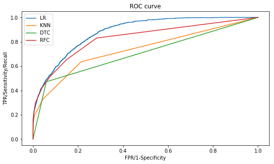

```python
plt.figure(figsize=(9,5))
plt.plot(false_positive_rate1,true_positive_rate1,label = "LR")
plt.plot(false_positive_rate2,true_positive_rate2,label = "KNN")
plt.plot(false_positive_rate3,true_positive_rate3,label = "DTC")
plt.plot(false_positive_rate4,true_positive_rate4,label = "RFC")
plt.ylabel("TPR/Sensitivity/Recall")
plt.xlabel("FPR/1-Specificity")
plt.title("ROC curve")
plt.legend()
```

### 8.2 Down Sampling

```python
from sklearn.utils import resample

# Separate majority and minority classes
df_majority = train_1[train_1.is_promoted==0]
df_minority = train_1[train_1.is_promoted==1]

# downsample majority class
df_minority_upsampled = resample(df_majority,
                                 replace=True,     # sample with replacement
                                 n_samples=4668,    # to match minority class
                                 random_state=123) # reproducible results

# Combine minority class with downsampled majority class
train_1= pd.concat([df_minority, df_minority_upsampled])

# Display new class counts
train_1.is_promoted.value_counts()
```

```
1    4668
0    4668
Name: is_promoted, dtype: int64
```

```python
import warnings
warnings.filterwarnings("ignore")

# splitting data into train and test

y=train_1.pop('is_promoted')
x=train_1


x_train,x_test,y_train,y_test=train_test_split(x,y,train_size=0.8,random_state=51)
print("x_train dimension : ",x_train.shape)
print("x_test dimension : ",x_test.shape)
print("y_train dimension : ",y_train.shape)
print("y_test dimension : ",y_test.shape)
```

```
x_train dimension :  (7468, 52)
x_test dimension :  (1868, 52)
y_train dimension :  (7468,)
y_test dimension :  (1868,)
```

```python
# there is no requirement of importing same libraries

fit1 = lr.fit(x_train,y_train) #fitting training data to logistic regression
fit2 = knn.fit(x_train,y_train) #fitting training data to knn
fit3 = dtc.fit(x_train,y_train) #fitting training data to Decision Tree Classifier
fit4 = rfc.fit(x_train,y_train) #fitting training data to Random Forest Classifier
```

```python
print("Accuracy Score of Logistic regression on train set",fit1.score(x_train,y_train)*100)
print("Accuracy Score of knn on train set",fit2.score(x_train,y_train)*100)
print("Accuracy Score of Decision Tree on train set",fit3.score(x_train,y_train)*100)
print("Accuracy Score of Random Forest on train set",fit4.score(x_train,y_train)*100)
```

```
Accuracy Score of Logistic regression on train set 79.45902517407606
Accuracy Score of knn on train set 82.67273701124799
Accuracy Score of Decision Tree on train set 99.93304767005891
Accuracy Score of Random Forest on train set 98.87520085698982
```

```python
# predicting target variable value for x_test dataset

y_pred1=fit1.predict(x_test)
y_pred2=fit2.predict(x_test)
y_pred3=fit3.predict(x_test)
y_pred4=fit4.predict(x_test)
```

```python
from sklearn.metrics import confusion_matrix
```

```python
print("For Logistic Regression:")

confusion=confusion_matrix(y_test,y_pred1)
print(confusion)
TN=confusion[0,0]
FP=confusion[0,1]
FN=confusion[1,0]
TP=confusion[1,1]

print("Accuracy :",(TP+TN)/(TP+TN+FP+FN))
print("Precision :",TP/(TP+FP))
print("Recall :",TP/(TP+FN))
precision=TP/(TP+FP)
recall=TP/(TP+FN)
print("F1 Score :",(2*precision*recall)/(precision+recall))

print("*"*71)

print("For KNN:")

confusion=confusion_matrix(y_test,y_pred2)
TN=confusion[0,0]
FP=confusion[0,1]
FN=confusion[1,0]
TP=confusion[1,1]

print("Accuracy :",(TP+TN)/(TP+TN+FP+FN))
print("Precision :",TP/(TP+FP))
print("Recall :",TP/(TP+FN))
precision=TP/(TP+FP)
recall=TP/(TP+FN)
print("F1 Score :",(2*precision*recall)/(precision+recall))

print("*"*71)

print("For Decision Tree:")

confusion=confusion_matrix(y_test,y_pred3)
TN=confusion[0,0]
FP=confusion[0,1]
FN=confusion[1,0]
TP=confusion[1,1]

print("Accuracy :",(TP+TN)/(TP+TN+FP+FN))
print("Precision :",TP/(TP+FP))
print("Recall :",TP/(TP+FN))
precision=TP/(TP+FP)
recall=TP/(TP+FN)
print("F1 Score :",(2*precision*recall)/(precision+recall))

print("*"*71)

print("For Random Forest:")

confusion=confusion_matrix(y_test,y_pred4)
TN=confusion[0,0]
FP=confusion[0,1]
FN=confusion[1,0]
TP=confusion[1,1]

print("Accuracy :",(TP+TN)/(TP+TN+FP+FN))
print("Precision :",TP/(TP+FP))
print("Recall :",TP/(TP+FN))
precision=TP/(TP+FP)
recall=TP/(TP+FN)
print("F1 Score :",(2*precision*recall)/(precision+recall))
```

```
For Logistic Regression:
[[690 243]
 [157 778]]
Accuracy : 0.7858672376873662
Precision : 0.761998041136141
Recall : 0.8320855614973262
F1 Score : 0.7955010224948875
For KNN:
Accuracy : 0.7168094218415417
Precision : 0.71875
Recall : 0.7133689839572193
F1 Score : 0.7160493827160493
For Decision Tree:
Accuracy : 0.7692719486081371
Precision : 0.7751091703056768
Recall : 0.7593582887700535
F1 Score : 0.7671528903295516
For Random Forest:
Accuracy : 0.771948608137045
Precision : 0.7704569606801275
Recall : 0.7754010695187166
F1 Score : 0.7729211087420041
```

```python
# this step is only to bring all in one dataframe

a_lr=accuracy_score(y_test,y_pred1)*100
a_knn=accuracy_score(y_test,y_pred2)*100
a_dtc=accuracy_score(y_test,y_pred3)*100
a_rfc=accuracy_score(y_test,y_pred4)*100

p_lr=precision_score(y_test,y_pred1)*100
p_knn=precision_score(y_test,y_pred2)*100
p_dtc=precision_score(y_test,y_pred3)*100
p_rfc=precision_score(y_test,y_pred4)*100

r_lr=recall_score(y_test,y_pred1)*100
r_knn=recall_score(y_test,y_pred2)*100
r_dtc=recall_score(y_test,y_pred3)*100
r_rfc=recall_score(y_test,y_pred4)*100

f_lr=f1_score(y_test,y_pred1)*100
f_knn=f1_score(y_test,y_pred2)*100
f_dtc=f1_score(y_test,y_pred3)*100
f_rfc=f1_score(y_test,y_pred4)*100

performance_df2=pd.DataFrame({'Accuracy':[a_lr,a_knn,a_dtc,a_rfc],
                            'Precision':[p_lr,p_knn,p_dtc,p_rfc],
                            'Recall':[r_lr,r_knn,r_dtc,r_rfc],
                            'F1 score':[f_lr,f_knn,f_dtc,f_rfc]},
                           index=['Logistic Regression', 'KNN', 'Decision Tree','Random Forest'])
performance_df2
```

|  | Accuracy | Precision | Recall | F1 score |
| --- | --- | --- | --- | --- |
| Logistic Regression | 78.586724 | 76.199804 | 83.208556 | 79.550102 |
| KNN | 71.680942 | 71.875000 | 71.336898 | 71.604938 |
| Decision Tree | 76.927195 | 77.510917 | 75.935829 | 76.715289 |
| Random Forest | 77.194861 | 77.045696 | 77.540107 | 77.292111 |

```python
# it is similar like .predict (it predict label for each observation) while
# .predict_proba (it predict probability for each observation)

y_pred_proba1=fit1.predict_proba(x_test)
y_pred_proba2=fit2.predict_proba(x_test)
y_pred_proba3=fit3.predict_proba(x_test)
y_pred_proba4=fit4.predict_proba(x_test)
```

```python
print("For Logistic Regression:")
false_positive_rate1,true_positive_rate1,thresholds1=roc_curve(y_test,y_pred_proba1[:,1])
roc_auc1=auc(false_positive_rate1,true_positive_rate1)
print("area under the roc curve :",roc_auc1)

print("For KNN:")
false_positive_rate2,true_positive_rate2,thresholds2=roc_curve(y_test,y_pred_proba2[:,1])
roc_auc2=auc(false_positive_rate2,true_positive_rate2)
print("area under the roc curve :",roc_auc2)

print("For Decision tree:")
false_positive_rate3,true_positive_rate3,thresholds3=roc_curve(y_test,y_pred_proba3[:,1])
roc_auc3=auc(false_positive_rate3,true_positive_rate3)
print("area under the roc curve :",roc_auc3)

print("For Random Forest:")
false_positive_rate4,true_positive_rate4,thresholds4=roc_curve(y_test,y_pred_proba4[:,1])
roc_auc4=auc(false_positive_rate4,true_positive_rate4)
print("area under the roc curve :",roc_auc4)
```

```
For Logistic Regression:
area under the roc curve : 0.8639229442142248
For KNN:
area under the roc curve : 0.7963237443471981
For Decision tree:
area under the roc curve : 0.7704036774019752
For Random Forest:
area under the roc curve : 0.8641355870029976
```

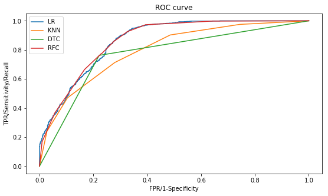

```python
plt.figure(figsize=(9,5))
plt.plot(false_positive_rate1,true_positive_rate1,label = "LR")
plt.plot(false_positive_rate2,true_positive_rate2,label = "KNN")
plt.plot(false_positive_rate3,true_positive_rate3,label = "DTC")
plt.plot(false_positive_rate4,true_positive_rate4,label = "RFC")
plt.ylabel("TPR/Sensitivity/Recall")
plt.xlabel("FPR/1-Specificity")
plt.title("ROC curve")
plt.legend()
```

### 8.3 Up Sampling

```python
# Separate majority and minority classes
df_majority = train_2[train_2.is_promoted==0]
df_minority = train_2[train_2.is_promoted==1]

# Upsample minority class
df_minority_upsampled = resample(df_minority,
                                 replace=True,     # sample with replacement
                                 n_samples=50140,    # to match majority class
                                 random_state=123) # reproducible results

# Combine majority class with upsampled minority class
train_2= pd.concat([df_majority, df_minority_upsampled])

# Display new class counts
train_2.is_promoted.value_counts()
```

```
1    50140
0    50140
Name: is_promoted, dtype: int64
```

```python
# splitting data into train and test

y=train_2.pop('is_promoted')
x=train_2


x_train,x_test,y_train,y_test=train_test_split(x,y,train_size=0.8,random_state=51)
print("x_train dimension : ",x_train.shape)
print("x_test dimension : ",x_test.shape)
print("y_train dimension : ",y_train.shape)
print("y_test dimension : ",y_test.shape)
```

```
x_train dimension :  (80224, 52)
x_test dimension :  (20056, 52)
y_train dimension :  (80224,)
y_test dimension :  (20056,)
```

```python
# there is no requirement of importing same libraries

fit1 = lr.fit(x_train,y_train) #fitting training data to logistic regression
fit2 = knn.fit(x_train,y_train) #fitting training data to knn
fit3 = dtc.fit(x_train,y_train) #fitting training data to Decision Tree Classifier
fit4 = rfc.fit(x_train,y_train) #fitting training data to Random Forest Classifier
```

```python
print("Accuracy Score of Logistic regression on train set",fit1.score(x_train,y_train)*100)
print("Accuracy Score of knn on train set",fit2.score(x_train,y_train)*100)
print("Accuracy Score of Decision Tree on train set",fit3.score(x_train,y_train)*100)
print("Accuracy Score of Random Forest on train set",fit4.score(x_train,y_train)*100)
```

```
Accuracy Score of Logistic regression on train set 79.32289589150379
Accuracy Score of knn on train set 93.70387913841245
Accuracy Score of Decision Tree on train set 99.88656761069007
Accuracy Score of Random Forest on train set 99.85540486637416
```

```python
# predicting target variable value for x_test dataset

y_pred1=fit1.predict(x_test)
y_pred2=fit2.predict(x_test)
y_pred3=fit3.predict(x_test)
y_pred4=fit4.predict(x_test)
```

```python
from sklearn.metrics import classification_report

print("For Logistic Regression:")
print(classification_report(y_test,y_pred1))

print("*"*71)

print("For KNN:")
print(classification_report(y_test,y_pred2))

print("*"*71)

print("For Decision Tree:")
print(classification_report(y_test,y_pred3))

print("*"*71)

print("For Random Forest:")
print(classification_report(y_test,y_pred4))
```

```
For Logistic Regression:
             precision    recall  f1-score   support

          0       0.81      0.77      0.79     10058
          1       0.78      0.82      0.80      9998

avg / total       0.80      0.79      0.79     20056

For KNN:
             precision    recall  f1-score   support

          0       1.00      0.82      0.90     10058
          1       0.85      1.00      0.92      9998

avg / total       0.92      0.91      0.91     20056

For Decision Tree:
             precision    recall  f1-score   support

          0       1.00      0.93      0.96     10058
          1       0.93      1.00      0.97      9998

avg / total       0.97      0.96      0.96     20056

For Random Forest:
             precision    recall  f1-score   support

          0       1.00      0.96      0.98     10058
          1       0.96      1.00      0.98      9998

avg / total       0.98      0.98      0.98     20056
```

```python
# this step is only to bring all in one dataframe

a_lr=accuracy_score(y_test,y_pred1)*100
a_knn=accuracy_score(y_test,y_pred2)*100
a_dtc=accuracy_score(y_test,y_pred3)*100
a_rfc=accuracy_score(y_test,y_pred4)*100

p_lr=precision_score(y_test,y_pred1)*100
p_knn=precision_score(y_test,y_pred2)*100
p_dtc=precision_score(y_test,y_pred3)*100
p_rfc=precision_score(y_test,y_pred4)*100

r_lr=recall_score(y_test,y_pred1)*100
r_knn=recall_score(y_test,y_pred2)*100
r_dtc=recall_score(y_test,y_pred3)*100
r_rfc=recall_score(y_test,y_pred4)*100

f_lr=f1_score(y_test,y_pred1)*100
f_knn=f1_score(y_test,y_pred2)*100
f_dtc=f1_score(y_test,y_pred3)*100
f_rfc=f1_score(y_test,y_pred4)*100

performance_df3=pd.DataFrame({'Accuracy':[a_lr,a_knn,a_dtc,a_rfc],
                            'Precision':[p_lr,p_knn,p_dtc,p_rfc],
                            'Recall':[r_lr,r_knn,r_dtc,r_rfc],
                            'F1 score':[f_lr,f_knn,f_dtc,f_rfc]},
                           index=['Logistic Regression', 'KNN', 'Decision Tree','Random Forest'])
performance_df3
```

|  | Accuracy | Precision | Recall | F1 score |
| --- | --- | --- | --- | --- |
| Logistic Regression | 79.467491 | 77.772530 | 82.346469 | 79.994170 |
| KNN | 90.840646 | 84.718795 | 99.589918 | 91.554411 |
| Decision Tree | 96.499801 | 93.447373 | 99.989998 | 96.608040 |
| Random Forest | 98.160152 | 96.449590 | 99.989998 | 98.187890 |

```python
# it is similar like .predict (it predict label for each observation) while
# .predict_proba (it predict probability for each observation)

y_pred_proba1=fit1.predict_proba(x_test)
y_pred_proba2=fit2.predict_proba(x_test)
y_pred_proba3=fit3.predict_proba(x_test)
y_pred_proba4=fit4.predict_proba(x_test)
```

```python
print("For Logistic Regression:")
false_positive_rate1,true_positive_rate1,thresholds1=roc_curve(y_test,y_pred_proba1[:,1])
roc_auc1=auc(false_positive_rate1,true_positive_rate1)
print("area under the roc curve :",roc_auc1)

print("For KNN:")
false_positive_rate2,true_positive_rate2,thresholds2=roc_curve(y_test,y_pred_proba2[:,1])
roc_auc2=auc(false_positive_rate2,true_positive_rate2)
print("area under the roc curve :",roc_auc2)

print("For Decision tree:")
false_positive_rate3,true_positive_rate3,thresholds3=roc_curve(y_test,y_pred_proba3[:,1])
roc_auc3=auc(false_positive_rate3,true_positive_rate3)
print("area under the roc curve :",roc_auc3)

print("For Random Forest:")
false_positive_rate4,true_positive_rate4,thresholds4=roc_curve(y_test,y_pred_proba4[:,1])
roc_auc4=auc(false_positive_rate4,true_positive_rate4)
print("area under the roc curve :",roc_auc4)
```

```
For Logistic Regression:
area under the roc curve : 0.877302424095875
For KNN:
area under the roc curve : 0.9667710883596485
For Decision tree:
area under the roc curve : 0.9657875003117545
For Random Forest:
area under the roc curve : 0.9990003518699364
```

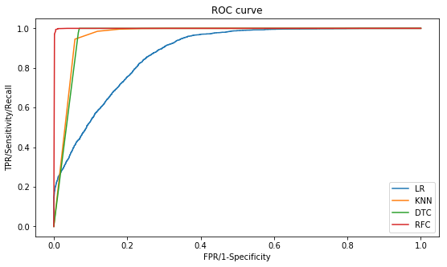

```python
plt.figure(figsize=(9,5))
plt.plot(false_positive_rate1,true_positive_rate1,label = "LR")
plt.plot(false_positive_rate2,true_positive_rate2,label = "KNN")
plt.plot(false_positive_rate3,true_positive_rate3,label = "DTC")
plt.plot(false_positive_rate4,true_positive_rate4,label = "RFC")
plt.ylabel("TPR/Sensitivity/Recall")
plt.xlabel("FPR/1-Specificity")
plt.title("ROC curve")
plt.legend()
```

### 8.4 SMOTE :

```python
# splitting data into train and test

y=train_3.pop('is_promoted')
x=train_3


x_train,x_test,y_train,y_test=train_test_split(x,y,train_size=0.8,random_state=51)
print("x_train dimension : ",x_train.shape)
print("x_test dimension : ",x_test.shape)
print("y_train dimension : ",y_train.shape)
print("y_test dimension : ",y_test.shape)
```

```
x_train dimension :  (43846, 52)
x_test dimension :  (10962, 52)
y_train dimension :  (43846,)
y_test dimension :  (10962,)
```

```python
print("Before OverSampling, counts of label '1': {}".format(sum(y_train == 1)))
print("Before OverSampling, counts of label '0': {} \n".format(sum(y_train == 0)))

# import SMOTE module from imblearn library

# pip install imblearn (if you don't have imblearn in your system)

from imblearn.over_sampling import SMOTE
sm = SMOTE(random_state = 123)
x_train, y_train= sm.fit_sample(x_train, y_train)

print('After OverSampling, the shape of train_X: {}'.format(x_train.shape))
print('After OverSampling, the shape of train_y: {} \n'.format(y_train.shape))

print("After OverSampling, counts of label '1': {}".format(sum(y_train == 1)))
print("After OverSampling, counts of label '0': {}".format(sum(y_train == 0)))
```

```
Before OverSampling, counts of label '1': 3742
Before OverSampling, counts of label '0': 40104

After OverSampling, the shape of train_X: (80208, 52)
After OverSampling, the shape of train_y: (80208,)

After OverSampling, counts of label '1': 40104
After OverSampling, counts of label '0': 40104
```

```python
# there is no requirement of importing same libraries

fit1 = lr.fit(x_train,y_train) #fitting training data to logistic regression
fit2 = knn.fit(x_train,y_train) #fitting training data to knn
fit3 = dtc.fit(x_train,y_train) #fitting training data to Decision Tree Classifier
fit4 = rfc.fit(x_train,y_train) #fitting training data to Random Forest Classifier
```

```python
# predicting target variable value for x_test dataset

y_pred1=fit1.predict(x_test)
y_pred2=fit2.predict(x_test)
y_pred3=fit3.predict(x_test)
y_pred4=fit4.predict(x_test)
```

```python
a_lr=accuracy_score(y_test,y_pred1)*100
a_knn=accuracy_score(y_test,y_pred2)*100
a_dtc=accuracy_score(y_test,y_pred3)*100
a_rfc=accuracy_score(y_test,y_pred4)*100

p_lr=precision_score(y_test,y_pred1)*100
p_knn=precision_score(y_test,y_pred2)*100
p_dtc=precision_score(y_test,y_pred3)*100
p_rfc=precision_score(y_test,y_pred4)*100

r_lr=recall_score(y_test,y_pred1)*100
r_knn=recall_score(y_test,y_pred2)*100
r_dtc=recall_score(y_test,y_pred3)*100
r_rfc=recall_score(y_test,y_pred4)*100

f_lr=f1_score(y_test,y_pred1)*100
f_knn=f1_score(y_test,y_pred2)*100
f_dtc=f1_score(y_test,y_pred3)*100
f_rfc=f1_score(y_test,y_pred4)*100

performance_df4=pd.DataFrame({'Accuracy':[a_lr,a_knn,a_dtc,a_rfc],
                            'Precision':[p_lr,p_knn,p_dtc,p_rfc],
                            'Recall':[r_lr,r_knn,r_dtc,r_rfc],
                            'F1 score':[f_lr,f_knn,f_dtc,f_rfc]},
                           index=['Logistic Regression', 'KNN', 'Decision Tree','Random Forest'])
performance_df4
```

|  | Accuracy | Precision | Recall | F1 score |
| --- | --- | --- | --- | --- |
| Logistic Regression | 77.257800 | 24.353519 | 80.345572 | 37.377543 |
| KNN | 75.871191 | 21.050859 | 67.494600 | 32.092426 |
| Decision Tree | 89.518336 | 39.143135 | 43.412527 | 41.167435 |
| Random Forest | 92.391899 | 60.952381 | 27.645788 | 38.038633 |

```python
# it is similar like .predict (it predict label for each observation) while
# .predict_proba (it predict probability for each observation)

y_pred_proba1=fit1.predict_proba(x_test)
y_pred_proba2=fit2.predict_proba(x_test)
y_pred_proba3=fit3.predict_proba(x_test)
y_pred_proba4=fit4.predict_proba(x_test)

print("For Logistic Regression:")
false_positive_rate1,true_positive_rate1,thresholds1=roc_curve(y_test,y_pred_proba1[:,1])
roc_auc1=auc(false_positive_rate1,true_positive_rate1)
print("area under the roc curve :",roc_auc1)

print("For KNN:")
false_positive_rate2,true_positive_rate2,thresholds2=roc_curve(y_test,y_pred_proba2[:,1])
roc_auc2=auc(false_positive_rate2,true_positive_rate2)
print("area under the roc curve :",roc_auc2)

print("For Decision tree:")
false_positive_rate3,true_positive_rate3,thresholds3=roc_curve(y_test,y_pred_proba3[:,1])
roc_auc3=auc(false_positive_rate3,true_positive_rate3)
print("area under the roc curve :",roc_auc3)

print("For Random Forest:")
false_positive_rate4,true_positive_rate4,thresholds4=roc_curve(y_test,y_pred_proba4[:,1])
roc_auc4=auc(false_positive_rate4,true_positive_rate4)
print("area under the roc curve :",roc_auc4)
```

```
For Logistic Regression:
area under the roc curve : 0.8792149019469436
For KNN:
area under the roc curve : 0.7713947391980663
For Decision tree:
area under the roc curve : 0.6868802010386797
For Random Forest:
area under the roc curve : 0.8221179671110569
```

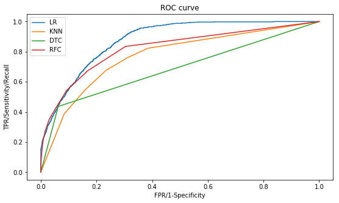

```python
plt.figure(figsize=(9,5))
plt.plot(false_positive_rate1,true_positive_rate1,label = "LR")
plt.plot(false_positive_rate2,true_positive_rate2,label = "KNN")
plt.plot(false_positive_rate3,true_positive_rate3,label = "DTC")
plt.plot(false_positive_rate4,true_positive_rate4,label = "RFC")
plt.ylabel("TPR/Sensitivity/Recall")
plt.xlabel("FPR/1-Specificity")
plt.title("ROC curve")
plt.legend()
```

## Comparision of results from all four techniques:

```python
performance_df1
```

|  | Accuracy | Precision | Recall | F1 score |
| --- | --- | --- | --- | --- |
| Logistic Regression | 93.066959 | 84.873950 | 21.814255 | 34.707904 |
| KNN | 92.565225 | 72.111554 | 19.546436 | 30.756160 |
| Decision Tree | 90.120416 | 42.371234 | 47.084233 | 44.603581 |
| Random Forest | 93.057836 | 71.208226 | 29.913607 | 42.129278 |

```python
performance_df2
```

|  | Accuracy | Precision | Recall | F1 score |
| --- | --- | --- | --- | --- |
| Logistic Regression | 78.586724 | 76.199804 | 83.208556 | 79.550102 |
| KNN | 71.680942 | 71.875000 | 71.336898 | 71.604938 |
| Decision Tree | 76.927195 | 77.510917 | 75.935829 | 76.715289 |
| Random Forest | 77.194861 | 77.045696 | 77.540107 | 77.292111 |

```python
performance_df3
```

|  | Accuracy | Precision | Recall | F1 score |
| --- | --- | --- | --- | --- |
| Logistic Regression | 79.467491 | 77.772530 | 82.346469 | 79.994170 |
| KNN | 90.840646 | 84.718795 | 99.589918 | 91.554411 |
| Decision Tree | 96.499801 | 93.447373 | 99.989998 | 96.608040 |
| Random Forest | 98.160152 | 96.449590 | 99.989998 | 98.187890 |

```python
performance_df4
```

|  | Accuracy | Precision | Recall | F1 score |
| --- | --- | --- | --- | --- |
| Logistic Regression | 77.257800 | 24.353519 | 80.345572 | 37.377543 |
| KNN | 75.871191 | 21.050859 | 67.494600 | 32.092426 |
| Decision Tree | 89.518336 | 39.143135 | 43.412527 | 41.167435 |
| Random Forest | 92.391899 | 60.952381 | 27.645788 | 38.038633 |

## 9. Saving the models

```python
import pickle
```

```python
pickle.dump(fit1, open('logistic.pkl','wb'))
pickle.dump(fit2, open('knn.pkl','wb'))
pickle.dump(fit3, open('dtc.pkl','wb'))
pickle.dump(fit4, open('rfc.pkl','wb'))
```

```python
logistic = pickle.load(open('logistic.pkl','rb'))
knn = pickle.load(open('knn.pkl','rb'))
dtc = pickle.load(open('dtc.pkl','rb'))
rfc = pickle.load(open('rfc.pkl','rb'))
```